# Exploring Food Deserts

### Food desert Population change over in US from 2010 to 2015:

```r
df2010$State_name <- as.factor(df2010$State_name)

LILA_df2010 <- df2010[df2010$LILATracts_1And10 == 1, c("POP2010", "State_name")]
LILA_df2015 <- data[data$LILATracts_1And10 == 1, c("POP2010", "State")]
colnames(LILA_df2015) <- c("POP2015", "State")
colnames(LILA_df2010) <- c("POP2010", "State")
```

In 2010, 37614936 of US Population lived in Food deserted tracts.

In 2015, 39416557 of US Population lived in Food deserted tracts.

Within 5 years, From 2010 to 2015, this population is `increased by 2 million`. Which is actually a alarming fact.

```r
library(dplyr)

summed_df_2015 <- LILA_df2015 %>%
  group_by(State) %>%
  summarise(POP2015 = sum(POP2015))

summed_df_2010 <- LILA_df2010 %>%
  group_by(State) %>%
  summarise(POP2010 = sum(POP2010))

merged_df <- full_join(summed_df_2015, summed_df_2010, by = "State")

merged_df$PopulationDifference <- merged_df$POP2015 - merged_df$POP2010
```

- This Graph shows the population of people in Food deserts by state in 2010 and 2015.

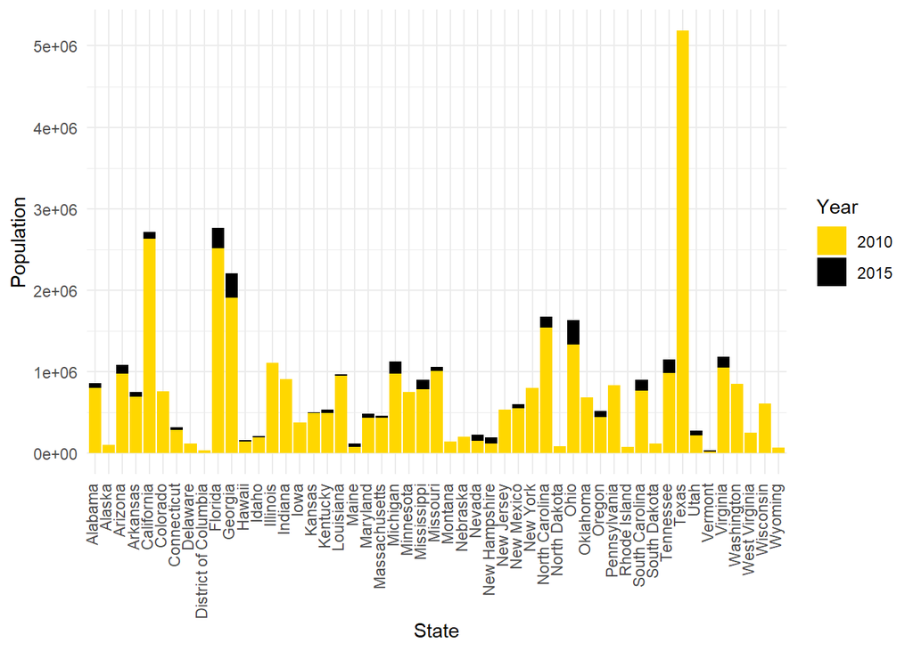

```r
# Create a bar chart
library(ggplot2)
p <- ggplot(merged_df, aes(x = State)) +
  geom_bar(aes(y = POP2015, fill = "2015"), stat = "identity", position = "dodge") +
  geom_bar(aes(y = POP2010, fill = "2010"), stat = "identity", position = "dodge") +
  labs(y = "Population", fill = "Year") +
  scale_fill_manual(values = c("2010" = "gold", "2015" = "black")) +
  theme_minimal() +
  theme(axis.text.x = element_text(angle = 90, hjust = 1, vjust=0.2))

options(
  repr.plot.width = 25,  # Set the desired width in inches
  repr.plot.height = 4  # Set the desired height in inches
)

print(p)
```

- Population difference in Food deserts from 2010 to 2015:

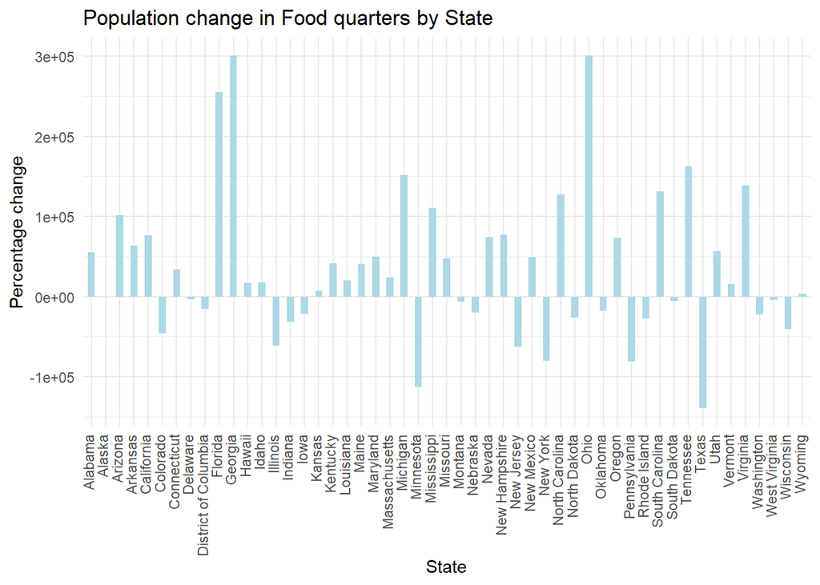

```r
bar_chart <- ggplot(merged_df, aes(x = State, y = PopulationDifference)) +
  geom_bar(stat = "identity", fill = "lightblue", width = 0.5) +
  labs(title = "Population change in Food quarters by State",
       x = "State",
       y = "Percentage change") +
  theme_minimal() +
  theme(axis.text.x = element_text(angle = 90, hjust = 1, vjust=0.2))

options(
  repr.plot.width = 25,  # Set the desired width in inches
  repr.plot.height = 4  # Set the desired height in inches
)

print(bar_chart)
```

- **Ohio, Georgia, and Florida have strong positive bars, indicating that the population rise is greater.**
- **Few states, like Texas and Minnesota, have seen a decline in the population of areas that are food deserts over time**
- MAP representation of population change:

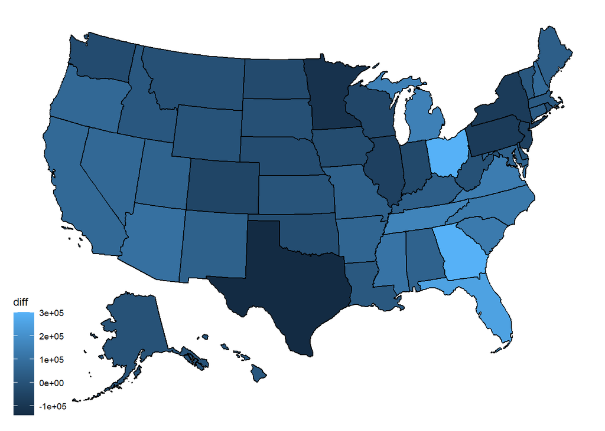

```r
library(usmap)

merged_dff <- merged_df[merged_df$State != "District of Columbia",]
merged_dff <- merged_dff[order(merged_dff$State),]
map_df <- data.frame(
  state = state.name,
  diff = merged_dff$PopulationDifference)

plot_usmap(data = map_df, values = "diff", labels = FALSE)
```

**The map shows that Eastern US states have experienced a greater population growth in food deserted areas than other US regions.**

# After EDA:

## Expectation difference after Exploratory Data Analysis

Upon examining the query, “What percentage of food deserts are classified as low-income tracts?”, we discovered that food deserts inherently embody a convergence of low income and limited access.

Also, The high poverty rate states are not correlated with food desert status. Which was different from our expectation.

# References

- [Strengthen SNAP Benefits. (2023, October 13)](https://frac.salsalabs.org/update-13october2023?eType=EmailBlastContent&eId=abd0e534-77e3-409c-957e-ae342b6d3f50)
- [FFAC Staff. (2022, April 05). What Are Food Deserts and Why Do They Exist? Factory Farming Awareness Coalition](https://ffacoalition.org/articles/food-deserts/)
- [FFRA Staff. (2023, October 25). Food Research & Action Center Calls for WIC Funding, SNAP Benefit Adequacy as Rates of Hunger Rise](https://frac.org/news/usdafoodinsecurityreport2023)